# Exercise 6 - Nonlinear Models and Tree-based Methods

Ng Jian Long

### Exercise 6.1

This question relates to the `College` dataset from the `ISLR` package.

1. Split the data into a training set and a test set. Using out-of-state tuition as the response and the other variables as the predictors, perform appropriate model selection of your choice (from day6) on the training set in order to identify a satisfactory model that uses just a subset of the predictors.

```r
library(ISLR)
library(glmnet, quietly = TRUE)
library(caTools, quietly = TRUE)

#Splitting data into training and test set
set.seed(1234)

sample = sample.split(College, SplitRatio = 0.7)
training <- subset(College, sample == TRUE)
test <- subset(College, sample == FALSE)

#Matrix x and vector y for training and test set
x.train <- model.matrix(Outstate ~ ., data = training)[, -1]
y.train <- training$Outstate

x.test <- model.matrix(Outstate ~., data = test)[, -1]
y.test <- test$Outstate

#Lasso Regression
cv.lasso <- cv.glmnet(x.train, y.train, alpha = 1)
lambda.lasso <- cv.lasso$lambda.min
lasso.train <- glmnet(x.train, y.train, alpha = 1, lambda = lambda.lasso)

lasso.coef <- predict(lasso.train, type = "coefficients", s = lambda.lasso)
lasso.coef
```

```
## 18 x 1 sparse Matrix of class "dgCMatrix"
##                        s1
## (Intercept) -681.94313880
## PrivateYes  2300.57755415
## Apps          -0.11989961
## Accept         0.67082344
## Enroll        -0.42745611
## Top10perc     22.13918988
## Top25perc      0.88328437
## F.Undergrad   -0.14128581
## P.Undergrad    .
## Room.Board     0.80014440
## Books          0.05239534
## Personal      -0.24203714
## PhD            3.31449027
## Terminal      29.79976447
## S.F.Ratio    -75.75361480
## perc.alumni   45.51220928
## Expend         0.17307464
## Grad.Rate     18.20984664
```

**Lasso regression is used to perform model selection. The lasso can shrink some of the regression coefficients to zero, effectively selecting a subset of the predictors that are most important for predicting the response variable. This is particularly useful in situations where we have a large number of predictors, and it is not clear which variables are most relevant.**

**Based on the coefficients, only `P.Undergrad` is reduced to zero. All other variables are deemed relevant to the model. This indicates that, while lasso does successfully identify a subset of relevant variables, it might not be the most effective method.**

**A brute force approach was proposed. In particular, the forward subset selection is attempted to identify a satisfactory model with only a subset of variables.**

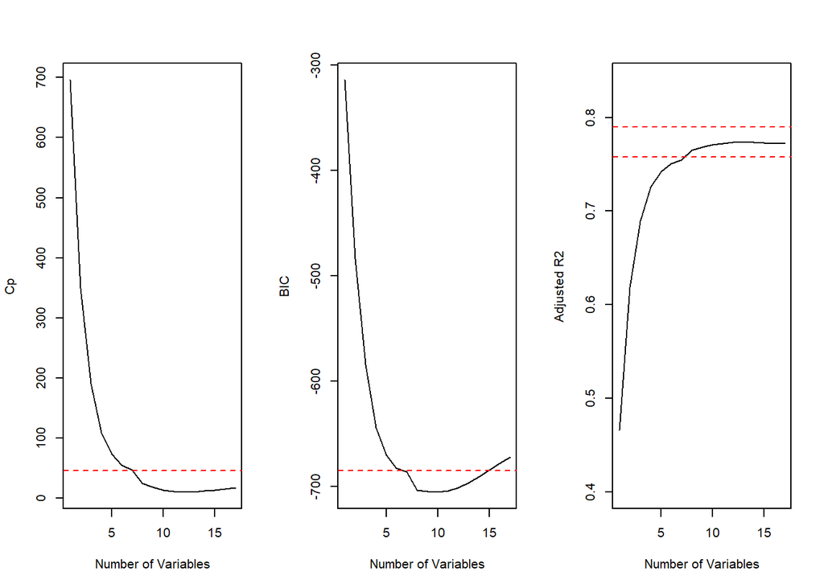

```r
library(leaps)

set.seed(1234)

#Forward selection
reg.fit <-  regsubsets(Outstate ~., data = training, nvmax = 17, method = "forward")
reg.summary <- summary(reg.fit)

#Plotting graphs for Mallow's Cp, AIC and BIC
par(mfrow = c(1, 3))
{
plot(reg.summary$cp, xlab="Number of Variables", ylab="Cp", type='l')
min.cp <-  min(reg.summary$cp)
std.cp <-  sd(reg.summary$cp)
abline(h = min.cp + 0.2 * std.cp, col="red", lty=2)
abline(h = min.cp - 0.2 * std.cp, col="red", lty=2)
plot(reg.summary$bic, xlab="Number of Variables", ylab="BIC", type='l')
min.bic <-  min(reg.summary$bic)
std.bic <-  sd(reg.summary$bic)
abline(h = min.bic + 0.2 * std.bic, col="red", lty=2)
abline(h = min.bic - 0.2 * std.bic, col="red", lty=2)
plot(reg.summary$adjr2, xlab = "Number of Variables",
     ylab = "Adjusted R2",type = 'l', ylim = c(0.4, 0.84))
max.adjr2 <-  max(reg.summary$adjr2)
std.adjr2 <-  sd(reg.summary$adjr2)
abline(h = max.adjr2 + 0.2 * std.adjr2, col="red", lty=2)
abline(h = max.adjr2 - 0.2 * std.adjr2, col="red", lty=2)
}
```

```r
reg.fit1 <-  regsubsets(Outstate ~ . , data = College, method = "forward")
reg.coef <-  coef(reg.fit1, id = 6)
names(reg.coef)
```

```
## [1] "(Intercept)" "PrivateYes"  "Room.Board"  "PhD"         "perc.alumni"
## [6] "Expend"      "Grad.Rate"
```

**The 6 variables to be included are `PrivateYes` `Room.Board`, `PhD`, `perc.alumni`, `Expend` and `Grad.Rate`.**

2. Fit a GAM on the training data, using out-of-state tuition as the response and the features selected in the previous step as the predictors. Plot the results, and explain your findings.

```r
library(gam)
```

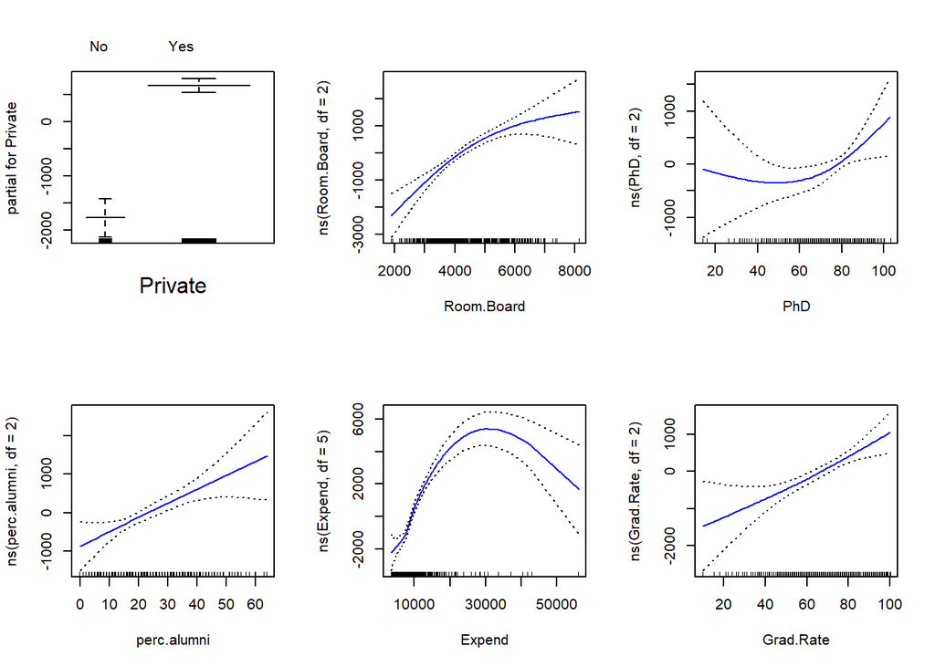

```r
gam.fit <-  gam(Outstate ~ Private + ns(Room.Board, df = 2) + ns(PhD, df = 2) + ns(perc.alumni, df = 2) +
                  ns(Expend, df = 5) + ns(Grad.Rate, df = 2), data = training)

par(mfrow=c(2, 3))
plot(gam.fit, se = TRUE, col = "blue")
```

**The plots show the estimated smoothing functions for each predictor variable in the model, along with their confidence intervals. The y-axis represents the estimated effect of each predictor on the response variable, while the x-axis represents the range of values of each predictor in the data. The blue line represents the estimated smooth function of the predictor variable. The black lines represent the pointwise standard errors of the estimate, which gives a measure of the uncertainty in the estimate of the smooth function.**

**Given that all the blue lines are located between the two black lines for all graphs, it means that the estimated smooth function is within one standard error of the estimate of the true smooth function. This suggests that the estimate of the smooth function is relatively precise and there is evidence that the true smooth function lies close to the estimated function.**

3. Evaluate the model obtained on the test set, and explain the results obtained.

```r
gam.pred <- predict(gam.fit, test)

gam.err <-  mean((test$Outstate - gam.pred)^2)
gam.tss <-  mean((test$Outstate - mean(test$Outstate))^2)
test.rss <-  1 - gam.err / gam.tss
test.rss
```

```
## [1] 0.7539387
```

4. For which variables, if any, is there evidence of a non-linear relationship with the response?

```r
summary(gam.fit)
```

```
##
## Call: gam(formula = Outstate ~ Private + ns(Room.Board, df = 2) + ns(PhD,
##     df = 2) + ns(perc.alumni, df = 2) + ns(Expend, df = 5) +
##     ns(Grad.Rate, df = 2), data = training)
## Deviance Residuals:
##      Min       1Q   Median       3Q      Max
## -7574.22 -1130.36   -14.01  1265.97  7649.17
##
## (Dispersion Parameter for gaussian family taken to be 3431715)
##
##     Null Deviance: 8483553039 on 518 degrees of freedom
## Residual Deviance: 1729584479 on 504 degrees of freedom
## AIC: 9299.845
##
## Number of Local Scoring Iterations: 2
##
## Anova for Parametric Effects
##                          Df     Sum Sq    Mean Sq F value    Pr(>F)
## Private                   1 2641377752 2641377752 769.696 < 2.2e-16 ***
## ns(Room.Board, df = 2)    2 2021135060 1010567530 294.479 < 2.2e-16 ***
## ns(PhD, df = 2)           2  985997409  492998705 143.660 < 2.2e-16 ***
## ns(perc.alumni, df = 2)   2  424847083  212423541  61.900 < 2.2e-16 ***
## ns(Expend, df = 5)        5  597748290  119549658  34.837 < 2.2e-16 ***
## ns(Grad.Rate, df = 2)     2   82862965   41431482  12.073 7.559e-06 ***
## Residuals               504 1729584479    3431715
## ---
## Signif. codes:  0 '***' 0.001 '**' 0.01 '*' 0.05 '.' 0.1 ' ' 1
```

### Exercise 6.2

Apply bagging and random forests to a data set of your choice. Be sure to fit the models on a training set and to evaluate their performance on a test set. How accurate are the results compared to simple methods like linear or logistic regression? Which of these approaches yields the best performance?

**The dataset chosen is the `Weekly` stock market price data from the ISLR package.**

```r
#Data preparation
set.seed(1234)

train <-  sample(nrow(Weekly), 2/3 * nrow(Weekly))
test <-  -train
```

**Logistic regression**

```r
glm.fit <-  glm(Direction ~ . -Year -Today, data = Weekly[train,], family = "binomial")
glm.probs <-  predict(glm.fit, newdata = Weekly[test, ], type = "response")
glm.pred <-  rep("Down", length(glm.probs))
glm.pred[glm.probs > 0.5] <-  "Up"
table(glm.pred, Weekly$Direction[test])
```

```
##
## glm.pred Down  Up
##     Down   18  24
##     Up    145 176
```

```r
glm.err <- mean(glm.pred != Weekly$Direction[test])
```

**Bagging**

```r
library(randomForest, quietly = TRUE)
Weekly <-  Weekly[,!(names(Weekly) %in% c("BinomialDirection"))]

bag.weekly <-  randomForest(Direction~.-Year -Today, data = Weekly, subset = train, mtry = 6)
yhat.bag <-  predict(bag.weekly, newdata = Weekly[test,])
table(yhat.bag, Weekly$Direction[test])
```

```
##
## yhat.bag Down  Up
##     Down   52  67
##     Up    111 133
```

```r
bag.err <- mean(yhat.bag != Weekly$Direction[test])
```

**Random forests**

```r
rf.weekly <-  randomForest(Direction ~ . -Year -Today, data = Weekly, subset = train, mtry = 2)

yhat.bag <-  predict(rf.weekly, newdata = Weekly[test,])
table(yhat.bag, Weekly$Direction[test])
```

```
##
## yhat.bag Down  Up
##     Down   43  61
##     Up    120 139
```

```r
rf.err <- mean(yhat.bag != Weekly$Direction[test])
```

```r
#Compiling Error Rates
library(knitr)

err.table <- cbind(glm.err, bag.err, rf.err)
colnames(err.table) <- c("Logistic", "Bagging", "Random Forest")
rownames(err.table) <- "Test Error Rate"
kable(err.table)
```

|  | Logistic | Bagging | Random Forest |
| --- | --- | --- | --- |
| Test Error Rate | 0.4655647 | 0.4903581 | 0.4986226 |

**Logistic Regression has the lowest test error rate.**